# Exchange Traded Funds

Harold Choi

26 Oct 2020

```r
library(QRM)
library(qrmtools)
library(readr)
library(tidyverse)
library(zoo)
library(xts)
library(quantmod)
library(ggplot2)
library(magrittr)
library(broom)
library(lubridate)
library(PerformanceAnalytics)
```

## Reading the data

- In this investigation, the following ETFs - VOO, QQQ, XBI, VYM are selected from NYSE which are listed in US and analyzed. Using the S&P500 to benchmark their performance with the each ETF is discussed and compared to in terms of several financial measures such as risk, returns, standard deviation, correlations. The data used is generated from Yahoo Finance from 2016-01-04 to 2020-10-21.
- ^GSPC: S&P500
- VOO: Vanguard 500 Index Fund ETF invests in stocks in the S&P 500 Index, representing 500 of the largest U.S. companies. As such, many benchmark indicators in the sections would be very similar if not the same as the S&P500. VOO offers high potential for investment growth, their share value rises and falls more sharply than that of funds holding bonds and is more appropriate for long-term goals where money growth is essential.
- QQQ: Tracks the Nasdaq 100 Index and focuses on large international and U.S. companies in the technology, healthcare, industrial, consumer discretionary, and telecommunications sectors. Where the S&P 500 tracks large-cap stocks across both major US stock exchanges, QQQ is limited to just the NASDAQ, so you can expect investment to be more heavily influenced by big news in the technology sector more than other industries.
- XBI: SPDR S&P Biotech ETF. XBI tracks an equal-weighted index of US biotechnology stocks. XBI is one of a handful of biotech ETFs available, offering exposure to a corner of the market that can perform well during periods of consolidation and is capable of big jumps in the event of major drug approvals.
- VYM: Vanguard High Dividend Yield ETF seeks to track the performance of the FTSE® High Dividend Yield Index, which measures the investment return of common stocks of companies characterized by high dividend yields. VYM provides a convenient way to track the performance of stocks that are forecasted to have above-average dividend yields and follows a passively managed, full-replication approach.

### Calculating returns

- The returns are calculated on a daily basis from 2016-01-24 to 2020-10-21 and an average is generated for each month. In total there are 57 monthly periods.

### Statistics

- Based on the table, QQQ has the highest average discrete monthly return 1.94%, VOO at 1.27%, XBI at 1.50%, VYM at 0.81%.
- In addition, standard deviation and variance are also useful for comparing the volatility of the returns of each ETF.
- Furthermore skewness of VOO, QQQ and VYM are less than -1 and are considered their returns are highly skewed.
- In terms of kurtosis which represents the heaviness of the tails of stock price, VOO and VYM has the heaviest extreme values. That means the investor will experience occasional extreme returns either positive or negative.

```r
table.Stats(etf1_return_discrete[,c(1:5)])
```

```
##                 GSPC.Adjusted VOO.Adjusted QQQ.Adjusted XBI.Adjusted
## Observations          57.0000      57.0000      57.0000      57.0000
## NAs                    1.0000       1.0000       1.0000       1.0000
## Minimum               -0.1907      -0.1894      -0.1573      -0.1756
## Quartile 1            -0.0015      -0.0001       0.0065      -0.0247
## Median                 0.0153       0.0172       0.0223       0.0169
## Arithmetic Mean        0.0110       0.0127       0.0194       0.0150
## Geometric Mean         0.0103       0.0120       0.0186       0.0130
## Quartile 3             0.0292       0.0312       0.0421       0.0648
## Maximum                0.0634       0.0655       0.0925       0.1587
## SE Mean                0.0049       0.0049       0.0054       0.0085
## LCL Mean (0.95)        0.0012       0.0028       0.0086      -0.0021
## UCL Mean (0.95)        0.0209       0.0226       0.0303       0.0322
## Variance               0.0014       0.0014       0.0017       0.0042
## Stdev                  0.0371       0.0371       0.0408       0.0645
## Skewness              -2.8888      -2.8856      -1.4522      -0.5396
## Kurtosis              13.6450      13.6314       4.5872       0.5254
##                 VYM.Adjusted
## Observations         57.0000
## NAs                   1.0000
## Minimum              -0.1964
## Quartile 1            0.0006
## Median                0.0132
## Arithmetic Mean       0.0081
## Geometric Mean        0.0074
## Quartile 3            0.0242
## Maximum               0.0604
## SE Mean               0.0047
## LCL Mean (0.95)      -0.0013
## UCL Mean (0.95)       0.0175
## Variance              0.0013
## Stdev                 0.0354
## Skewness             -3.4312
## Kurtosis             17.7366
```

## Performance charts

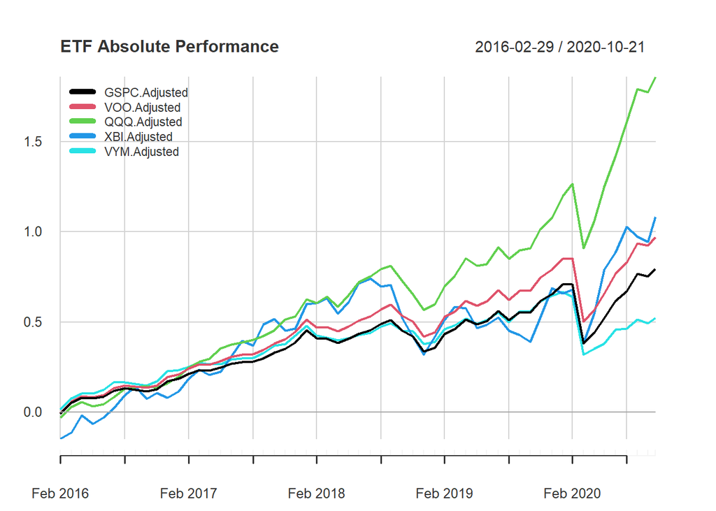

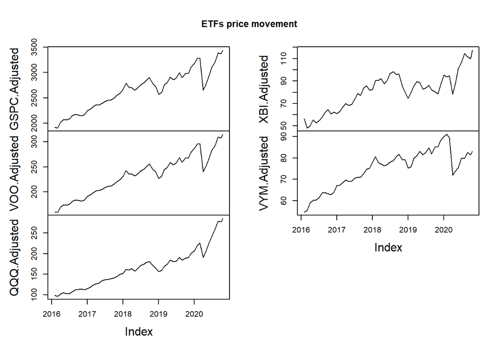

## Value at Risk

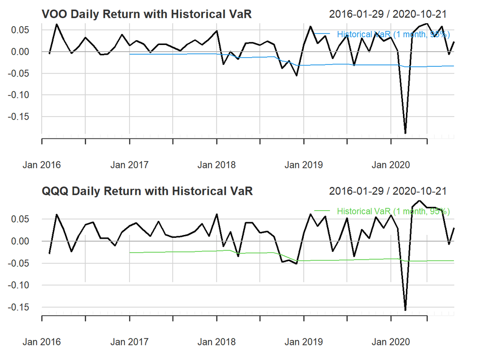

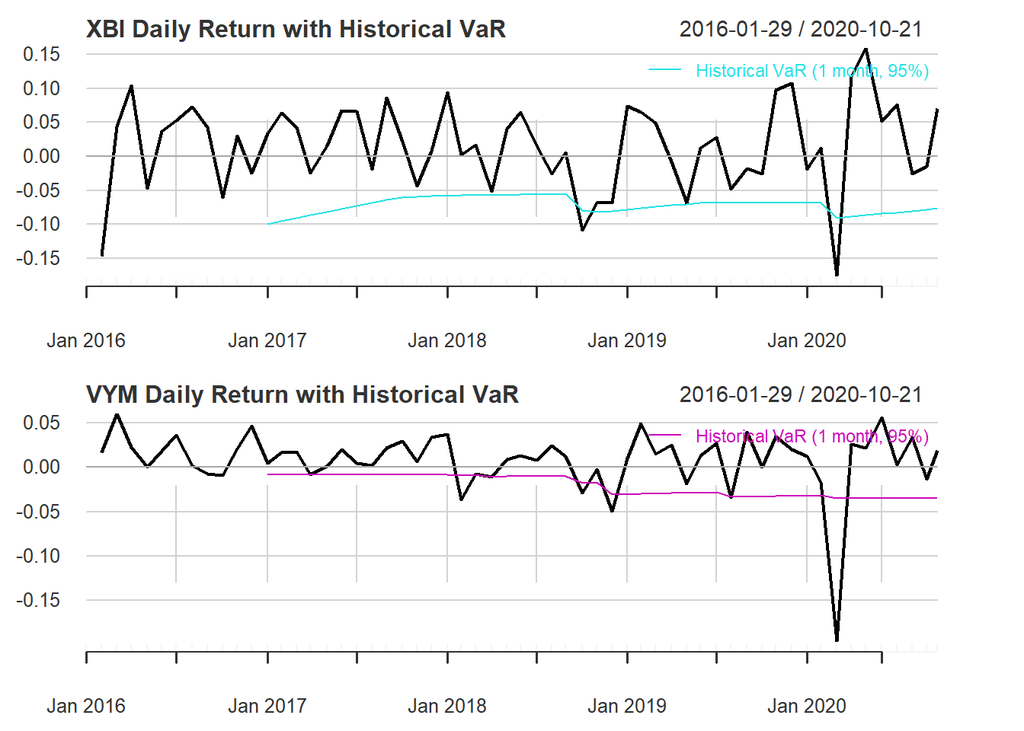

## Drawdown

- The drawdown refers to how much the ETF has dropped down from the peak before it recovers back to the peak. XBI appears to have the greatest negative drawdown which means the highest downside volatility.

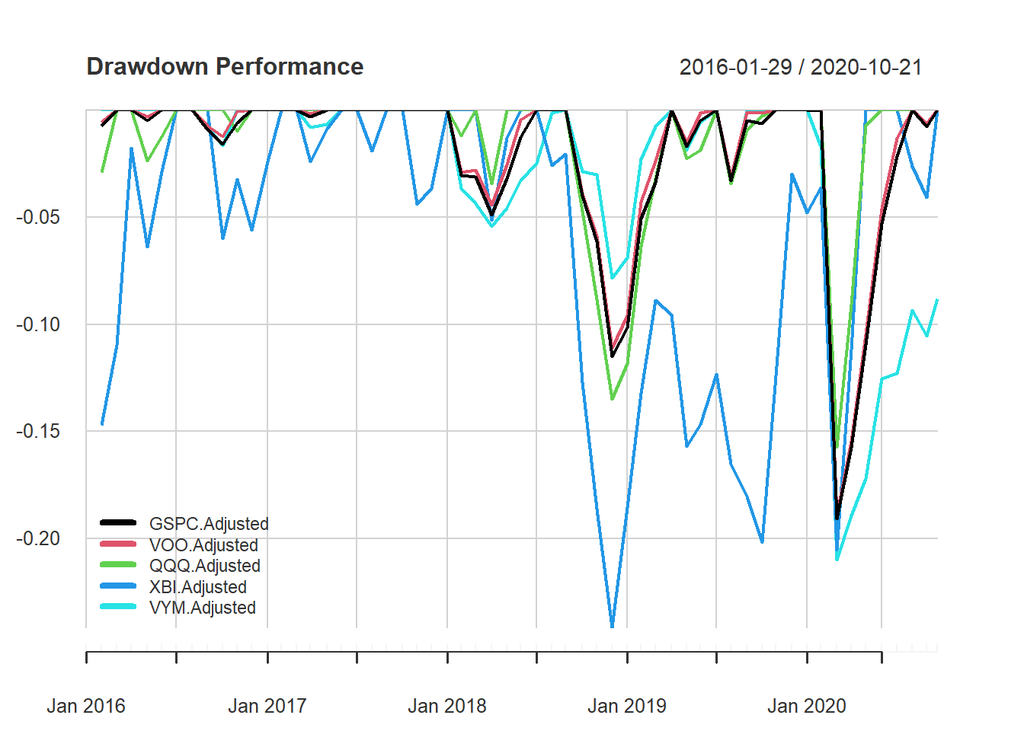

## Comparing distribution using boxplots

- XBI has the greatest variability and highest standard deviation of stock price, 6.45%. VYM has the smallest variability among the 5 investments and this shows that VYM has the lowest volatility in terms of discrete returns.

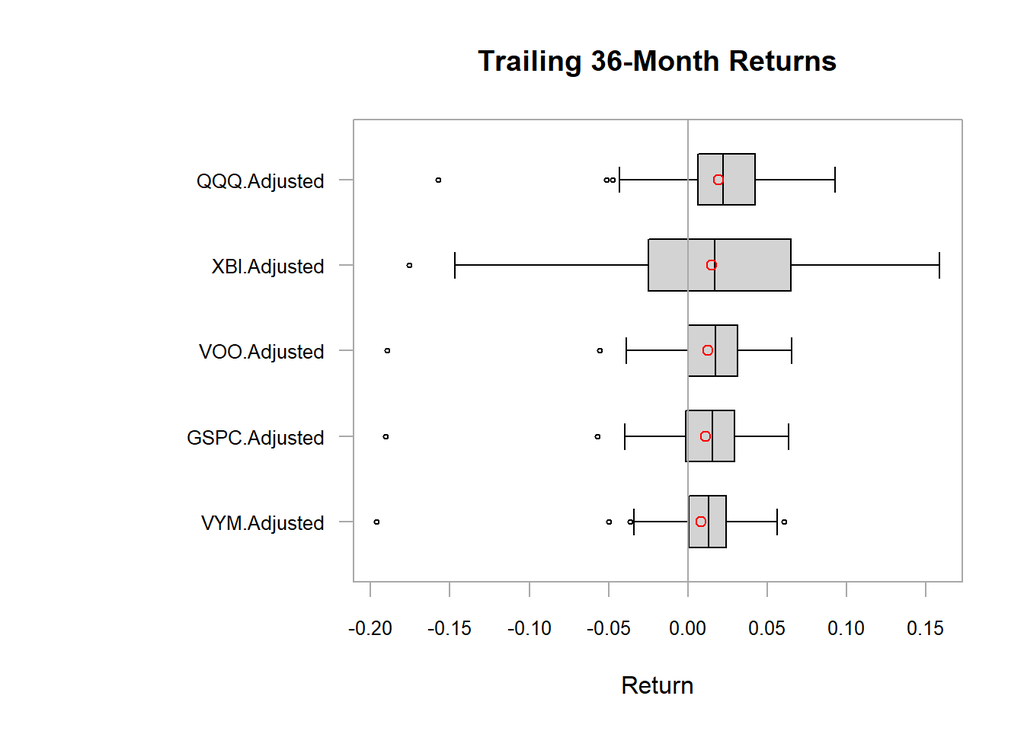

## Risk vs Return

- The three lines plot show the slope of 1,2,3 for the sharpe ratio.
- VOO offers the higher annualized return for almost the same annualized risk as VYM.
- In addition, QQQ has the strongest return-risk reward while XBI has the highest annualized risk.

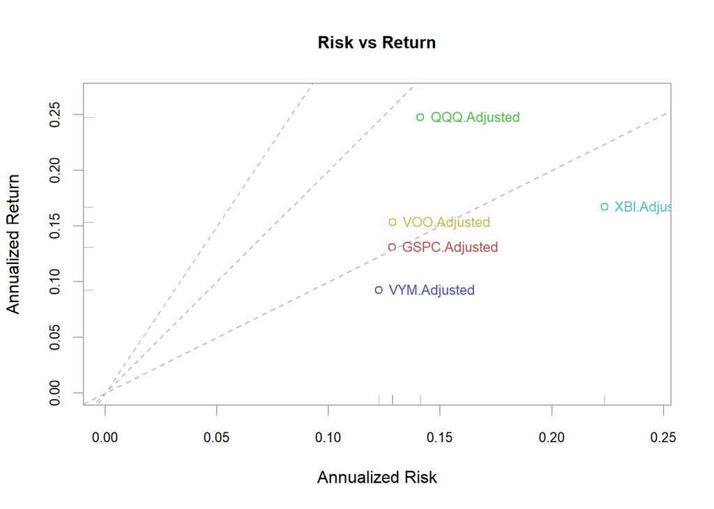

## Measuring performance consistency

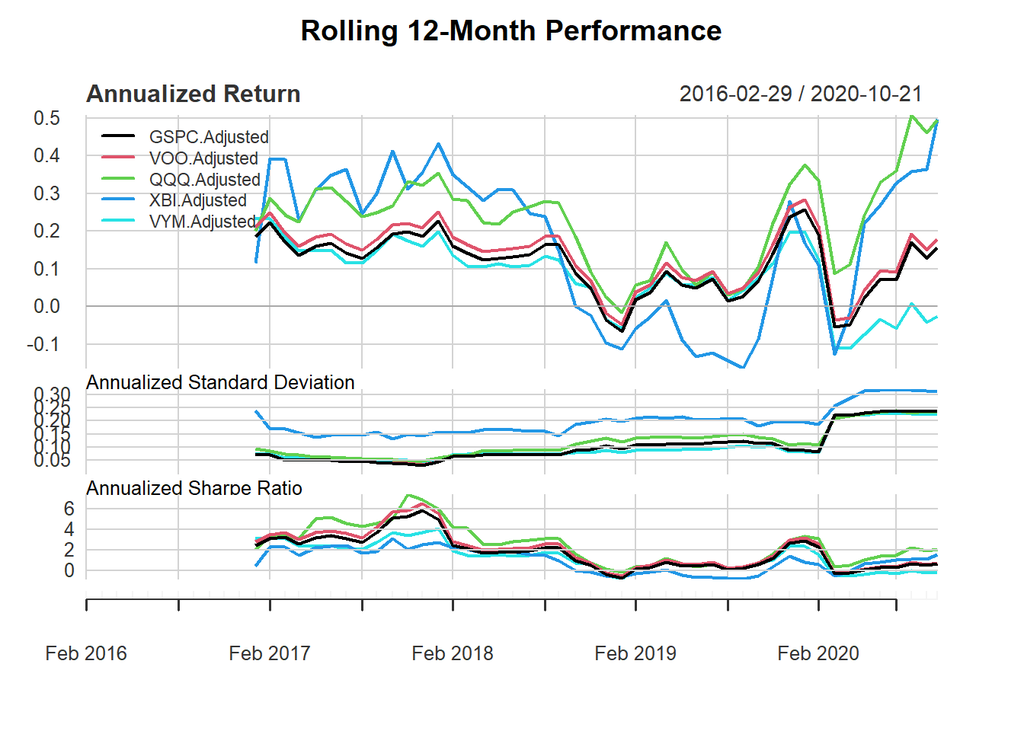

## Measuring relative performance

- Identifying and using a benchmark can help assess and explain how well in terms of meeting investment objectives. In this case, the S&P500 is used as a benchmark.
- QQQ performs well relative to the benchmark and XBI has managed to climb and reach its peak in 2020 due to the coronavirus effect and the biomedical research industry that XBI captures.

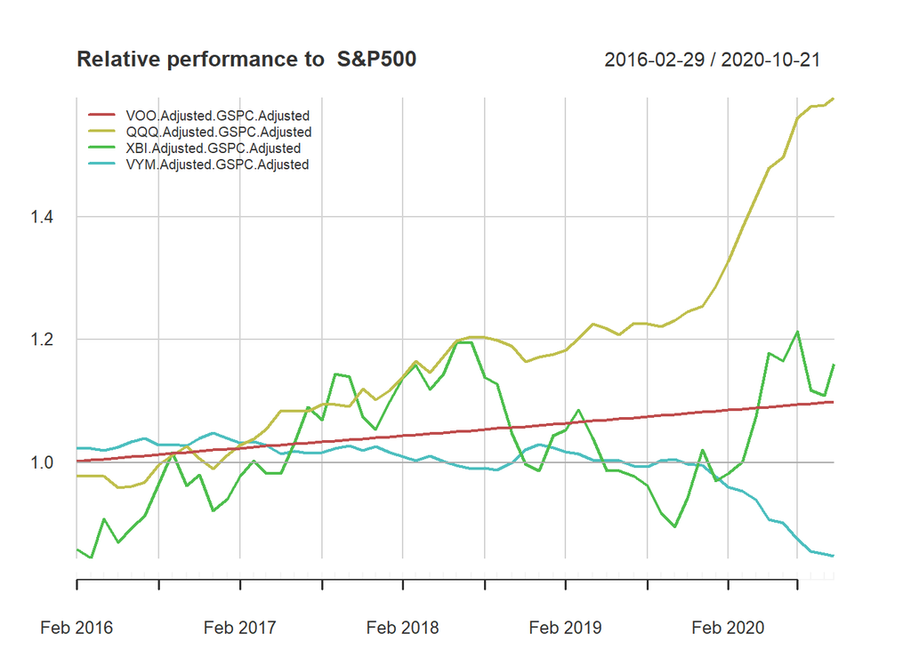

### CAPM numerics

- QQQ has the highest alpha at 0.82% based off a monthly period.
- XBI has the highest beta at 1.1795, theoretically more volative than the market. While VYM has the lowest beta at 0.9151, theoretically less volatile than the market.
- XBI has a relative low R squared, 0.4587 almost two times lower than QQQ and VYM, this effectively means XBI does not move in as much tandem with the S&P500 benchmark as compared to QQQ, VYM and VOO.
- QQQ has the highest Treynor ratio which indicates that it generated 0.24 excess return for each unit of risk taken on.

```r
table.CAPM(etf1_return_discrete[,c(2:5), drop =FALSE],
           etf1_return_discrete[,c(1),drop =FALSE],)
```

```
##                     VOO.Adjusted to GSPC.Adjusted QQQ.Adjusted to GSPC.Adjusted
## Alpha                                      0.0016                        0.0082
## Beta                                       1.0023                        1.0139
## Beta+                                      1.0018                        1.1571
## Beta-                                      1.0019                        0.8701
## R-squared                                  0.9999                        0.8494
## Annualized Alpha                           0.0199                        0.1035
## Correlation                                1.0000                        0.9216
## Correlation p-value                        0.0000                        0.0000
## Tracking Error                             0.0011                        0.0548
## Active Premium                             0.0226                        0.1164
## Information Ratio                         21.0871                        2.1232
## Treynor Ratio                              0.1533                        0.2441
##                     XBI.Adjusted to GSPC.Adjusted VYM.Adjusted to GSPC.Adjusted
## Alpha                                      0.0020                       -0.0020
## Beta                                       1.1795                        0.9151
## Beta+                                      0.6183                        0.7278
## Beta-                                      0.8049                        1.0151
## R-squared                                  0.4587                        0.9177
## Annualized Alpha                           0.0245                       -0.0242
## Correlation                                0.6772                        0.9580
## Correlation p-value                        0.0000                        0.0000
## Tracking Error                             0.1661                        0.0368
## Active Premium                             0.0361                       -0.0386
## Information Ratio                          0.2172                       -1.0477
## Treynor Ratio                              0.1417                        0.1010
```

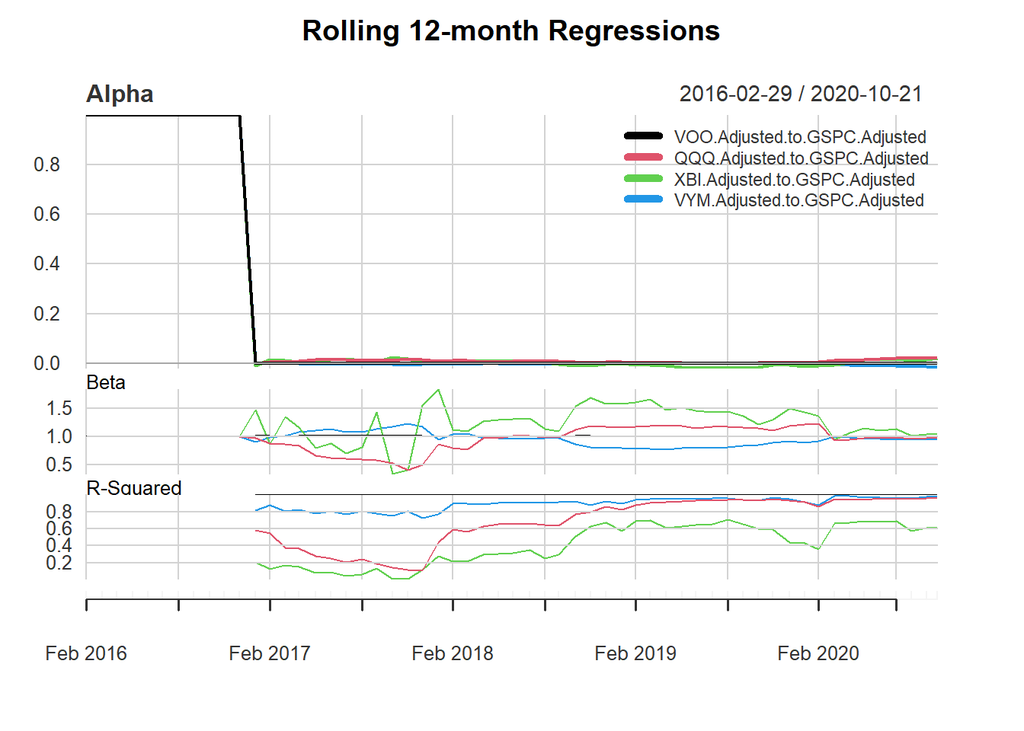

```r
charts.RollingRegression(etf1_return_discrete[,c(2:5), drop =FALSE],
                         etf1_return_discrete[,c(1),drop =FALSE],
                        lwd = 5,
                         legend.loc = "topright")
```

## Correlation

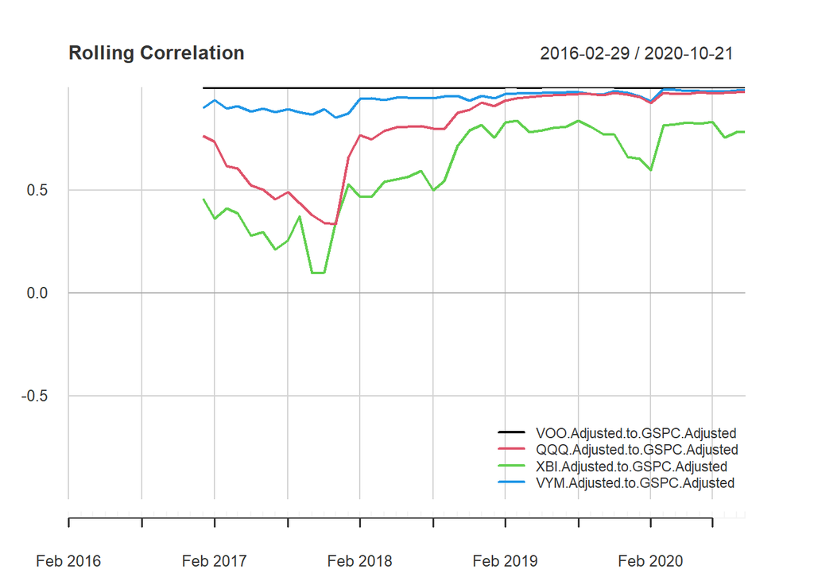

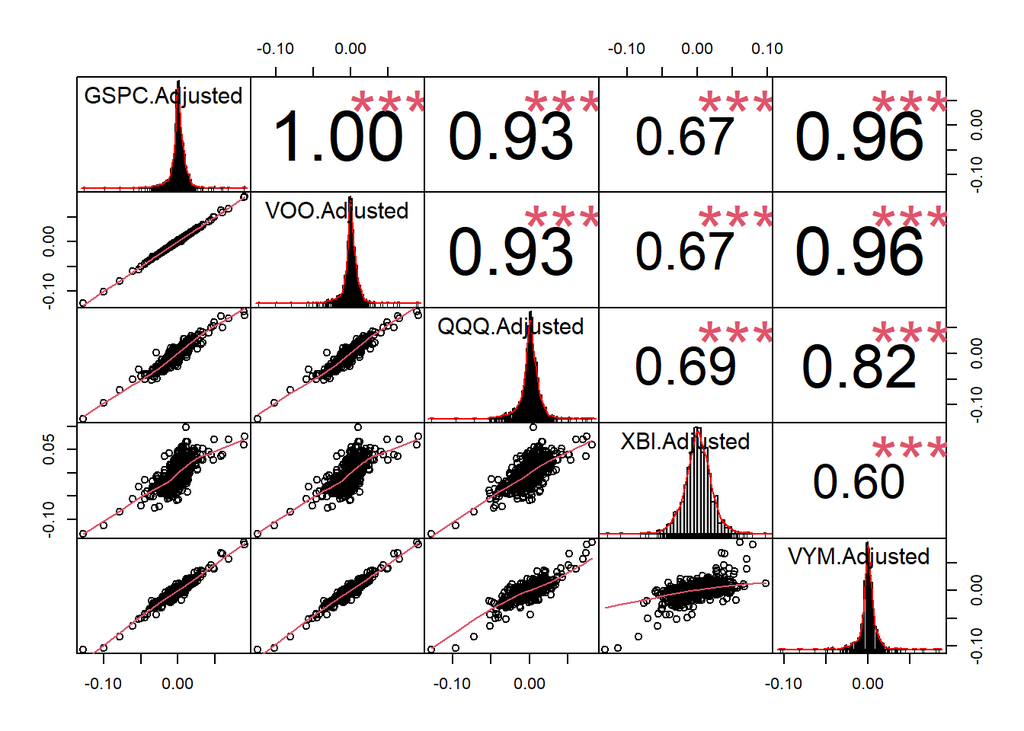

## Downside Risk

- Semi deviation looks only at negative price fluctuation and is an alternative measurement to standard deviation or variance. It is used to evaluate the downside risk of an investment. A higher number represents greater fluctuations in the negative price of the ETF.
- Gain deviation is a similar calculation to standard deviation and the opposite of loss deviation. It calculates the deviation using only up period returns, variances and the number of up periods. A higher number means there is more deviation in the gains of the ETF.
- Loss deviation is similar to standard deviation but calculates the deviation using only the down period returns, variances and number of down periods.

```r
table.DownsideRisk(etf1_return_discrete[,1:5])
```

```
##                              GSPC.Adjusted VOO.Adjusted QQQ.Adjusted
## Semi Deviation                      0.0316       0.0316       0.0324
## Gain Deviation                      0.0161       0.0168       0.0230
## Loss Deviation                      0.0452       0.0473       0.0399
## Downside Deviation (MAR=10%)        0.0306       0.0301       0.0280
## Downside Deviation (Rf=0%)          0.0280       0.0276       0.0251
## Downside Deviation (0%)             0.0280       0.0276       0.0251
## Maximum Drawdown                    0.1909       0.1894       0.1573
## Historical VaR (95%)               -0.0343      -0.0328      -0.0440
## Historical ES (95%)                -0.0960      -0.0946      -0.0852
## Modified VaR (95%)                 -0.0637      -0.0622      -0.0584
## Modified ES (95%)                  -0.1566      -0.1553      -0.1160
##                              XBI.Adjusted VYM.Adjusted
## Semi Deviation                     0.0483       0.0307
## Gain Deviation                     0.0361       0.0151
## Loss Deviation                     0.0440       0.0494
## Downside Deviation (MAR=10%)       0.0449       0.0308
## Downside Deviation (Rf=0%)         0.0409       0.0283
## Downside Deviation (0%)            0.0409       0.0283
## Maximum Drawdown                   0.2416       0.2101
## Historical VaR (95%)              -0.0763      -0.0344
## Historical ES (95%)               -0.1438      -0.0941
## Modified VaR (95%)                -0.0990      -0.0636
## Modified ES (95%)                 -0.1371      -0.1557
```